# Reproducible Research - Peer Assessment 1

## Introduction

It is now possible to collect a large amount of data about personal movement using activity monitoring devices such as a Fitbit, Nike Fuelband, or Jawbone Up. But these data remain under-utilized both because the raw data are hard to obtain and there is a lack of statistical methods and software for processing and interpreting the data.

For this project, we will use the data collected to do simple analysis on the personal activity.

## Data

This assignment makes use of data from a personal activity monitoring device. This device collects data at 5 minute intervals through out the day. The data consists of two months of data from an anonymous individual collected during the months of October and November, 2012 and include the number of steps taken in 5 minute intervals each day.

The variables included in this dataset are:  
**steps**: Number of steps taking in a 5-minute interval (missing values are coded as NA)  
**date**: The date on which the measurement was taken in YYYY-MM-DD format  
**interval**: Identifier for the 5-minute interval in which measurement was taken  
The dataset is stored in a comma-separated-value (CSV) file and there are a total of 17,568 observations in this dataset.

## Assignment

**Step 1:** Loading and preprocessing the data

```r
# Read data
dataset <- read.csv("./Project 1/activity.csv", header = TRUE, sep = ",")

# Convert date
dataset$date <- as.Date(dataset$date, format = "%Y-%m-%d")
```

**Step 2:** What is mean total number of steps taken per day?

- Calculate the total number of steps taken per day, ingnore NA values
- Plot the histgram
- Report the mean and median

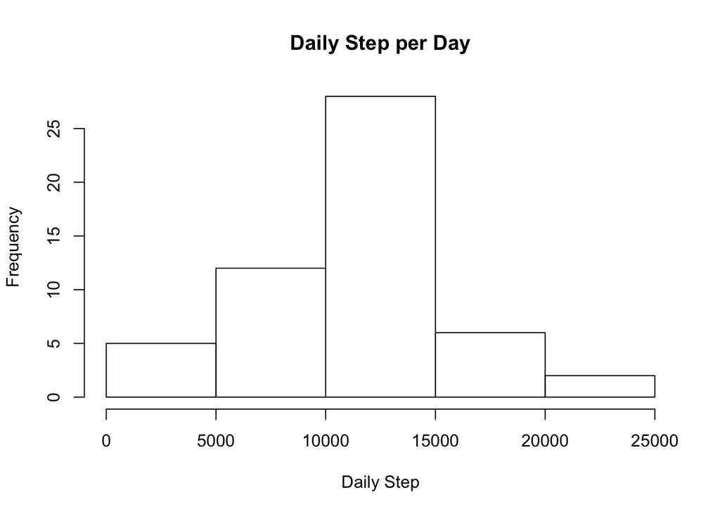

```r
## Calculate the total number of steps taken per day, ingnore NA values
dailystep <- aggregate(steps ~ date, data = dataset, sum, na.rm = TRUE)
## Plot the histgram
hist(dailystep$steps, main = "Daily Step per Day", xlab = "Daily Step")
```

```r
## Report the mean and median
mean(dailystep$steps)
```

```
## [1] 10766.19
```

```r
median(dailystep$steps)
```

```
## [1] 10765
```

**Step 3:** What is the average daily activity pattern?

- Get average number of steps for 5-minute interval averaged across all days
- Make a time-series plot
- Get the maximum steps along with the 5-minute interval

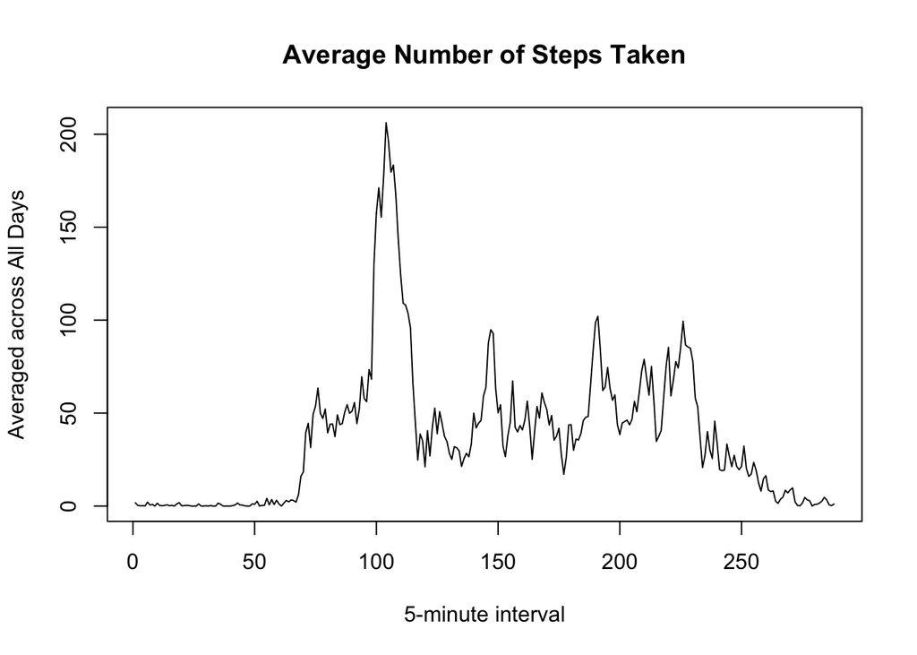

```r
## Get average number of steps for 5-minute interval averaged across all days
averagestep <- tapply(dataset$steps, dataset$interval, mean, na.rm = TRUE)
## Make a time-series plot
plot(averagestep, type = "l", main = "Average Number of Steps Taken", xlab = "5-minute interval", ylab = "Averaged across All Days")
```

```r
## Get the maximum steps along with the 5-minute interval
index <- which.max(averagestep)
max(averagestep)
```

```
## [1] 206.1698
```

```r
names(index)
```

```
## [1] "835"
```

**Step 4:** Imputing missing values

- Report the total number of missing values
- Create new dataset with all missing values filled by the mean for that 5-minute interval calculated in step 3
- Make a histgram with new dataset
- Report the mean and median for new dataset
- Report the difference in mean and median between raw data and new data
- **Conclusion:** There is no difference for mean value. Filling in the missing data changed the median value for daily steps.

```r
## Report the total number of missing values
NAnumber <- sum(is.na(dataset))
NAnumber
```

```
## [1] 2304
```

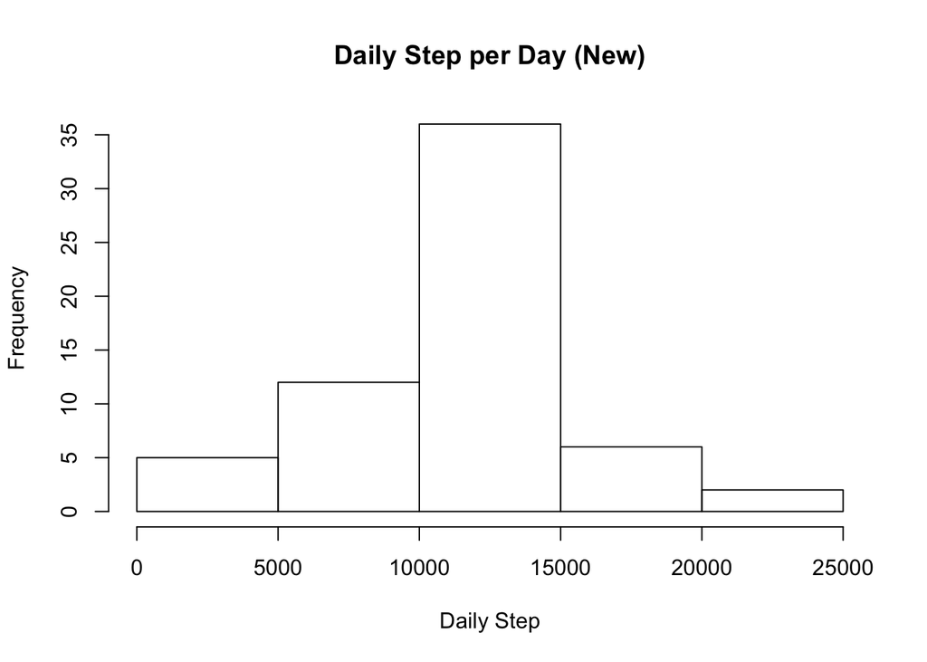

```r
## Create new dataset with all missing values filled by the mean for that 5-minute interval calculated in step 3
filldataset <- dataset
averagestepDF <- cbind.data.frame(interval = as.integer(names(averagestep)), avgsteps = unname(averagestep))
temp <- sapply(unique(dataset$interval), function (x) filldataset[!complete.cases(filldataset) & (filldataset$interval == x), 1] <<- averagestepDF$avgsteps[averagestepDF$interval == x])
## Make a histgram with new dataset
filldailystep <- aggregate(steps ~ date, data = filldataset, sum, na.rm = TRUE)
hist(filldailystep$steps, main = "Daily Step per Day (New)", xlab = "Daily Step")
```

```r
## Report the mean and median for new dataset
mean(filldailystep$steps)
```

```
## [1] 10766.19
```

```r
median(filldailystep$steps)
```

```
## [1] 10766.19
```

```r
## Report the difference in mean and median between raw data and new data
mean(filldailystep$steps) - mean(dailystep$steps)
```

```
## [1] 0
```

```r
median(filldailystep$steps) - median(dailystep$steps)
```

```
## [1] 1.188679
```

**Step 5:** Are there differences in activity patterns between weekdays and weekends?

- Create a factor indicating weekday or weekend
- Make a panel plot

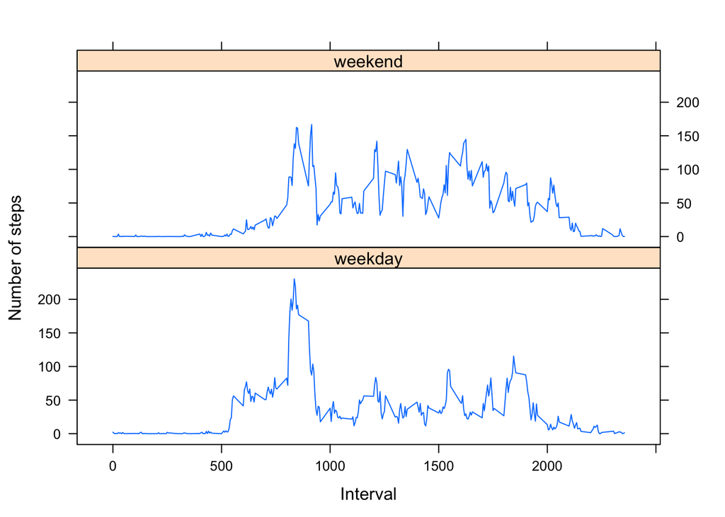

```r
## Create a factor indicating weekday or weekend
filldataset$date <- as.Date(filldataset$date, format = "%Y-%m-%d")
filldataset$weekdayIndex <- "weekday"
filldataset$weekdayIndex[weekdays(filldataset$date) %in% c("Saturday", "Sunday")] <- "weekend"
filldataset$weekdayIndex <- as.factor(filldataset$weekdayIndex)
averagestepIn <- aggregate(steps ~ interval + weekdayIndex, data = filldataset, mean)
## Make a panel plot
library(lattice)
xyplot(steps ~ interval | weekdayIndex, averagestepIn, type = "l", layout = c(1, 2), xlab = "Interval", ylab = "Number of steps")
```